# Course Project: Shiny Application and Reproducible Pitch

15/07/2019

## Overview

This presentation is the **supporting documentation** for a **Shiny Application and Reproducible Pitch** developed for the Week 4 assignment of the **Coursera Developing Data Products course**.

- **Introduction to the application**
- **Application Name:** Playing With Iris Dataset and Machine Learning Algorithms
- **Based on:** Shiny framework + JavaScript codes + “iris” dataset
- **Required R Packages:** shiny, psych, scatterplot3d, ggplot2, gridExtra, grid, caret, kernlab, randomForest, e1071
- **Objective of the application**
- With this interactive application you will be able to **(1)** sample and view the “iris” dataset as a table, **(2)** generate multiple pre-defined graphs with the sampled dataset, **(3)** explore multiple pre-defined machine learning algorithms for Specie predictions and finally **(4)** test prediction with these algorithms.
- For modeling there is also an option to adjust cross-validation controls (number of folds and repetitions) before running the selected model.
- All the R codes for generating graphs, models and prediction are displayed in each corresponding panel.

## Application Description

The application consists of 4 Panels, each one with variables setting and specific results as follows:

- **Panel 1 - Explore Data Set** This panel is dedicated to sample and resample the iris data set as many timeS desired. Changing the sample size of the iris dataset will affect all the subsequent panels (graphs, machine learning modeling and prediction). All settings referring to this panel are in **red** font color.
- **Panel 2 - Explore Vizualizations** This panel is dedicated to plot the sampled iris data set in many pre-defined graph formats. Changing the graph types will only affect the results of this Panel. All settings referring to this panel are in **green** font color.
- **Panel 3 - Explore Models** This panel is dedicated to select machine learning algorithms and cross-validation variables (folds and repetitions). Changing the model types, number of folds an repetitions may affect the results of the prediction Panel. All settings referring to this panel are in **blue** font color.
- **Panel 4 - Try Your Own Specie Predictions** This panel is dedicated to input values to Petal.Width, Petal.Length, Sepal.Width and Sepal.Length and see the result for Specie Prediction. All settings referring to this panel are in **darkorchid** font color.

## Application Print Screen

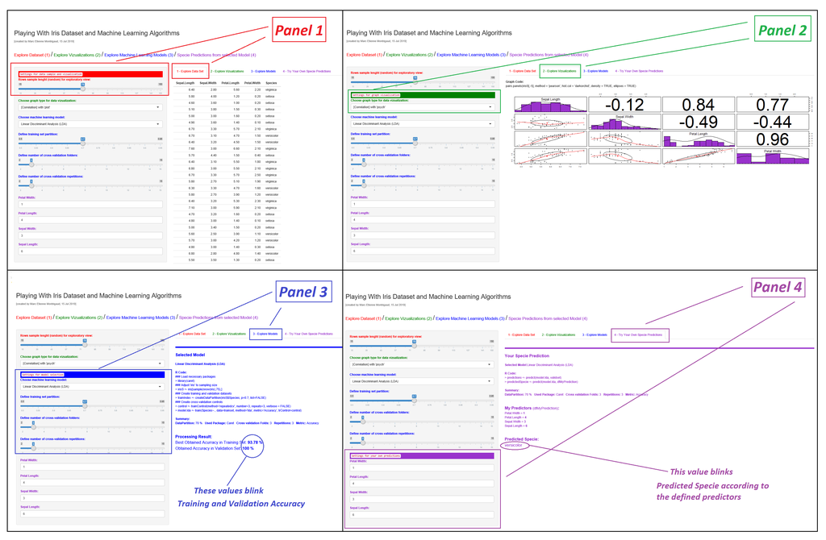

## Application and Code Links

- **Apllication Deployed at** https://marcetienne.shinyapps.io/CourseraDevDataProdWeek4/
- **Apllication Code at** https://github.com/1234-marc/Developing-Data-Products

**Based on Iris Data Set as follows:**

```r
library(xtable)
print(xtable(head(iris,10)), type = "html")
```

|  | Sepal.Length | Sepal.Width | Petal.Length | Petal.Width | Species |
| --- | --- | --- | --- | --- | --- |
| 1 | 5.10 | 3.50 | 1.40 | 0.20 | setosa |
| 2 | 4.90 | 3.00 | 1.40 | 0.20 | setosa |
| 3 | 4.70 | 3.20 | 1.30 | 0.20 | setosa |
| 4 | 4.60 | 3.10 | 1.50 | 0.20 | setosa |
| 5 | 5.00 | 3.60 | 1.40 | 0.20 | setosa |
| 6 | 5.40 | 3.90 | 1.70 | 0.40 | setosa |
| 7 | 4.60 | 3.40 | 1.40 | 0.30 | setosa |
| 8 | 5.00 | 3.40 | 1.50 | 0.20 | setosa |
| 9 | 4.40 | 2.90 | 1.40 | 0.20 | setosa |
| 10 | 4.90 | 3.10 | 1.50 | 0.10 | setosa |